# Final Exam Review

## Technical Details

- **Regular Exam Date:** 15th of December, 2002, 10:00-11:30, [online](http://pruefung.uni-mannheim.de)
- **Alternative Exam Date:** 8th of February, 2023, time tba, online

You will have a maximum of 90 minutes to complete the exam, plus an extra 5 minutes “buffer” should any technical issues arise.

To get a sense of how the system works, you can take a “mock test” [**here.**](https://pruefung.uni-mannheim.de/goto.php?target=crs_7237_rcode9Dqj2LnD3n&client_id=ILIAS)

Any problems occurring during the exam time (e.g. internet disruptions) must be reported to me or Alex immediately.

You may contact us via email or zoom:

- Email Nan
- Email Alex
- https://uni-mannheim.zoom.us/my/nanzhangresearch
- Meeting ID: 716 461 3644
- Password: 567859

## Exam Content

The Final Exam will only cover topics directly addressing each week’s **learning goals.** These learning goals are found at the top of each week’s slides, and are collected [**here.**](https://nanzhangresearch.github.io/edsc_learninggoals.html)

The exam will consist of **5 short answer** questions.

Each question is worth 12 points (60 in total).

Each question will be graded on content (8 points) and organization / structure (4 points).

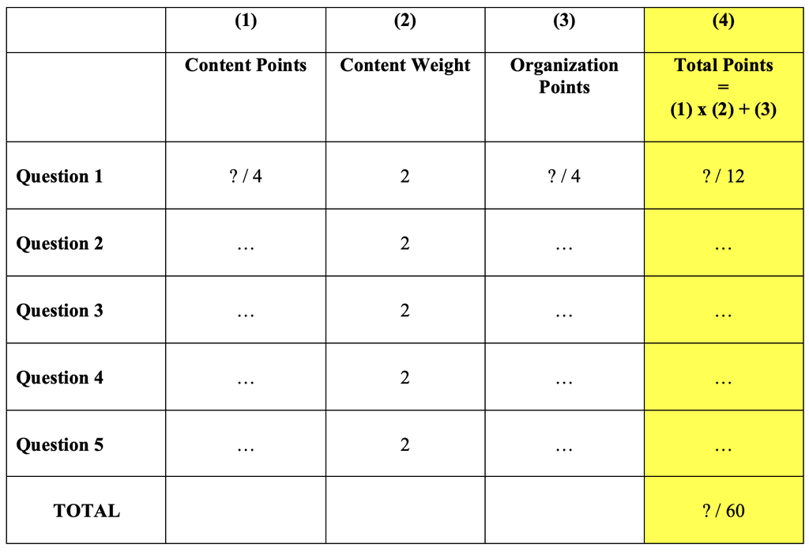

The grading criteria are as follows:

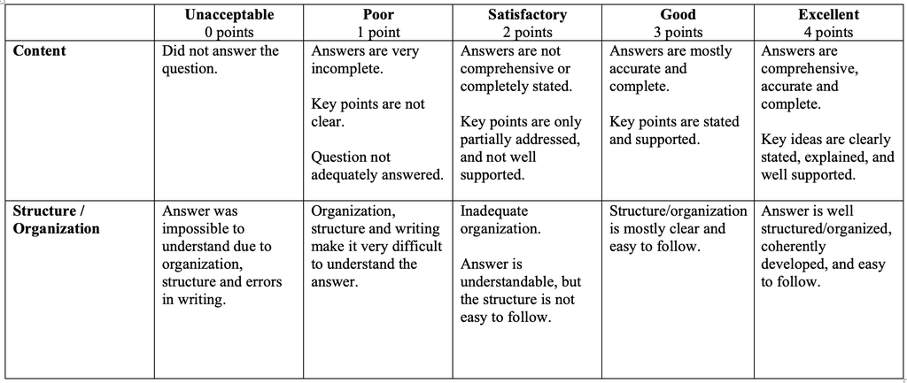

Points will be converted into final grades as follows:

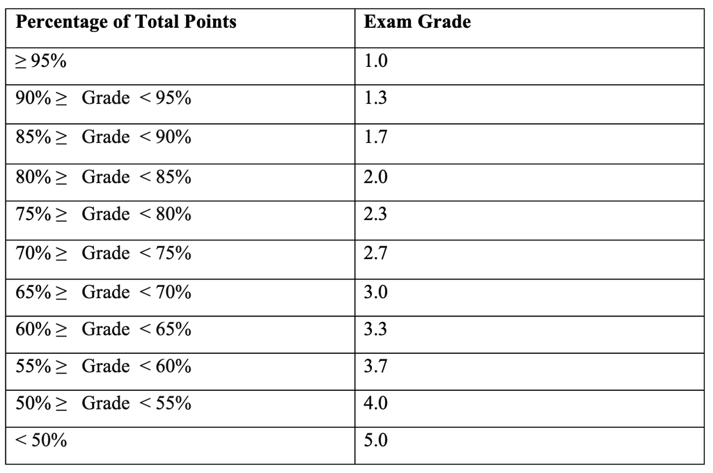

**Sample Question 1**

Two friends, Lukas and Hakan, want to start studying in a large German student city next semester. They were both born in Germany, but Hakan’s parents immigrated from Turkey, so Hakan has a (visible) Turkish migration background.

Both Lukas and Hakan want to find a shared flat in order to quickly make new friends in the city. As it just so happens, they both see an advertisement for a free room in a shared flat located near the University. The German student Jörg already lives in the apartment - he also gets to decide who can move in and who cannot.

Lukas and Hakan both reply to the advertisement and are invited to view the flat and get to know Jörg. Hakan visits the flat on Monday morning and Lukas on Monday afternoon.

During the conversation, Jörg asks both of them the same question: “I’m looking for a roommate who has lived in a shared flat before. Do you have any experience with shared flats?” Neither Lukas nor Hakan have shared flat experience, but both mention that, while growing up, they had siblings with whom they had to share housework (washing dishes, cleaning the bathroom, taking out the trash, etc.).

Jörg tells Hakan that, unfortunately, he cannot move in since he has no shared flat experience. However, Jörg gives a different answer to Lukas, telling him that “sharing chores with siblings seems pretty similar to sharing a flat” and offering him the room on the spot.

Lukas and Hakan run into each other on Tuesday and start talking about their experiences looking for a flat. They are surprised to learn that they both visited Jörg’s flat. Lukas is also shocked when Hakan tells him the reason that Jörg rejected him.

Lukas gets angry and confronts Jörg, accusing him of racism. Jörg denies this and protests that he is not prejudiced. He did, after all, invite Hakan to see the flat. He also claims that he has participated in many demonstrations against the AfD - a far-right party known for its strong anti-immigrant positions.

Suppose that Jörg genuinely believes that he is not prejudiced. What do you think happened here? More specifically, how would you explain Jörg’s behavior given his (genuine) beliefs about himself?

Please give detailed reasons for your answer.

**Sample Question 2**

Amy (who is white) and Bob (who is black) have lived all their lives in Carterville.

10 years ago, the racial composition in Carterville was:

- 70% White
- 10% Black
- 10% Hispanic
- 10% Asian

Carterville has become more diverse in recent years. Now the racial composition is:

- 55% White
- 20% Black
- 15% Hispanic
- 10% Asian

Suppose we conduct a study in which, in each year over the last decade, we ask Amy and Bob the following question:

*Imagine that you lost your wallet containing your wallet containing your ID and 200 USD in Carterville and it was found by another Carterville resident. Do you think your wallet (or your valuables) would be returned to you?*

**Question part 1 (30%)**: From the perspective of Conflict Theory, how should Carterville’s demographic changes over the past decade affect Amy’s answers to this question?

In other words, compared to 10 years ago, is she likely (i) more likely, (ii) less likely, or (iii) about equally likely to say that her wallet would be returned?

Please explain your answer.

**Question part 2 (30%)**: And what about Bob? From the perspective of Conflict Theory, how should Carterville’s demographic changes affect Bob’s answers to this question?

Again, please explain your answer.

**Question part 3 (40%)**: Now take the perspective of Constrict Theory. What would Constrict Theory predict about how Carterville’s demographic changes affect Amy’s level of trust? Bob’s?

Again, please explain your answer.

**Sample Question 3**

Here’s a question based closely on Ryan Enos’ field experiment on train platforms.

Recall that Enos was interested in how exposure to immigration shapes anti-immigrant attitudes.

For the purposes of this question, suppose the study was exactly conducted like this:

1. On 30 July 2016, Enos administered a baseline survey to train commuters across 20 train platforms in the Boston area.
2. Between 1 August and 30 August 2016, Enos sends Hispanic confederates to 10 of these train platforms (treatment group). Confederates are instructed to stay at the platform for the whole morning. The remaining 10 platforms constitute the control group.
3. On 1 September 2016, Enos contacts everyone who filled out the baseline survey and asks them to now fill out an endline survey within the next week.

The outcome of interest is the within-person change in prejudice scores between the baseline and endline surveys. Enos compares the average magnitude of this within-person change amongst people who were waiting at the treatment platforms against those waiting at the control platforms. He finds an average treatment effect equivalent to a 10 percentage point reduction on his prejudice scale.

Unfortunately, it turns out that some people who took the baseline survey didn’t respond to Enos’ request to take the endline survey. In other words, some people dropped out of the study (a problem commonly known as attrition).

When Enos carefully inspects the data, he finds that the vast majority of dropouts happen to be strong Trump supporters. Further, most dropouts also happened to live near two train stations on the rail-line running from Boston to the remote village of Waltham. It turns out that Trump was hosting a week-long “Make America Great Again” conference in Waltham during the first week of September. Presumably, many Trump supporters living near these stations decided to take advantage of the easy train connection to attend the conference, and were consequently too busy to fill out Enos’ endline survey.

Finally, by random chance, it so happens that these two stations on the Boston-Waltham line were assigned to the treatment group and regularly visited by Enos’ Hispanic confederates in August.

Given these facts, how do you think the problem of attrition affected the average treatment effect detected in this study? In other words, if Trump’s conference had not taken place, do you think Enos would have found an average treatment effect that was (a) larger than 10 percentage points, (b) smaller than 10 percentage points, or (c) around the same size?

Please explain your reasoning in full, including any assumptions you would make about how the dropouts would have likely responded to the treatment in comparison to those who did not drop out.